# R: Plot a component relation graph

| plotSoilRelationGraph {sharpshootR} | R Documentation |
| --- | --- |

## Plot a component relation graph

### Description

Plot a component relation graph based on an adjacency or similarity matrix.

### Usage

```
plotSoilRelationGraph(m, s='', plot.style='network', spanning.tree=NULL,
del.edges=NULL, vertex.scaling.factor=2, edge.scaling.factor=1,
edge.transparency=1, edge.col=grey(0.5), edge.highlight.col='royalblue',
g.layout=layout.fruchterman.reingold,
...)
```

### Arguments

| `m` | adjacency matrix |
| --- | --- |
| `s` | central component; an empty character string is interpreted as no central component |
| `plot.style` | plot style ('network', or 'dendrogram') |
| `spanning.tree` | plot the minimim or maximum spaning tree ('min', 'max'), or, max spanning tree plus edges with weight greater than the n-th quantile specified in 'spanning.tree'. See details and examples. |
| `del.edges` | optionally delete edges with weights less than the specified quantile (0-1) |
| `vertex.scaling.factor` | scaling factor applied to vertex size |
| `edge.scaling.factor` | optional scaling factor applied to edge width |
| `edge.transparency` | optional transparency setting for edges (0-1) |
| `edge.col` | edge color, applied to all edges |
| `edge.highlight.col` | edge color applied to all edges connecting to component named in `s` |
| `g.layout` | an igraph layout function, defaults to `layout.fruchterman.reingold` |
| `...` | further arguments passed to plotting function |

### Details

Vertex size is based on a normalized index of connectivity: size = sqrt(degree(g)/max(degree(g))) * scaling.factor. Edge width can be optionally scaled by edge weight by specifying an `edge.scaling.factor` value. The maximum spanning tree represents a sub-graph where the sum of edge weights are maximized. The mimimum spanning tree represents a sub-graph where the sum of edge weights are minimized. The maximum spanning tree is likely a more useful simplification of the full graph, in which only the strongest relationships (e.g. most common co-occurrences) are preserved.

The maximum spanning tree + edges with weights > n-th quantile is an experimental hybrid. The 'backbone' of the graph is created by the maximum spanning tree, and augmented by 'strong' auxillary edges– defined by a value between 0 and 1.

### Value

an igraph 'graph' object is invisibly returned

### Note

This function is a work in progress, ideas welcome.

### Author(s)

D.E. Beaudette

### Examples

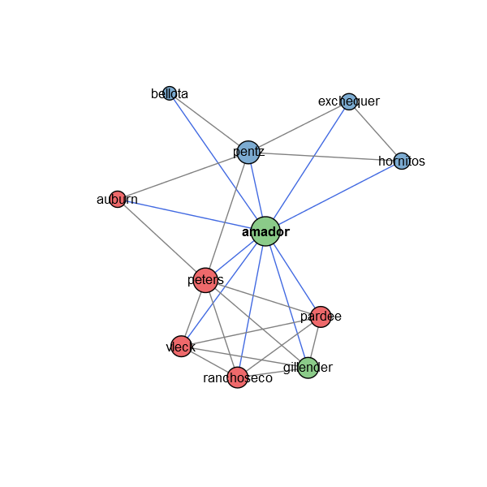

```r
# load sample data set
data(amador)

# create weighted adjacency matrix (see ?component.adj.matrix for details)
m <- component.adj.matrix(amador)

# plot network diagram, with Amador soil highlighted
plotSoilRelationGraph(m, s='amador')
```

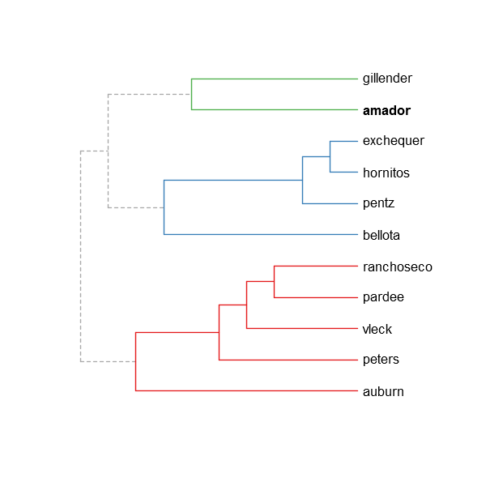

```r
# dendrogram representation
plotSoilRelationGraph(m, s='amador', plot.style='dendrogram')
```

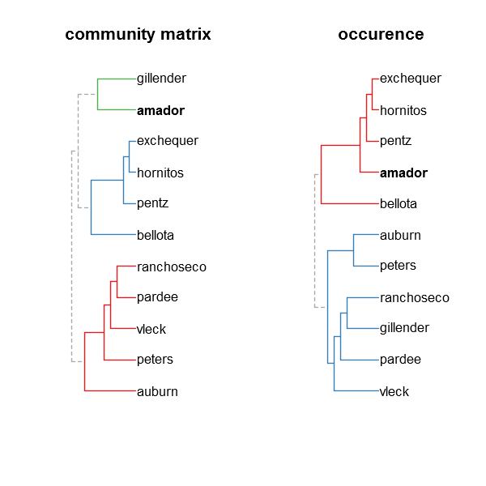

```r
# compare methods
m.o <- component.adj.matrix(amador, method='occurrence')

par(mfcol=c(1,2))
plotSoilRelationGraph(m, s='amador', plot.style='dendrogram')
title('community matrix')
plotSoilRelationGraph(m.o, s='amador', plot.style='dendrogram')
title('occurence')
```

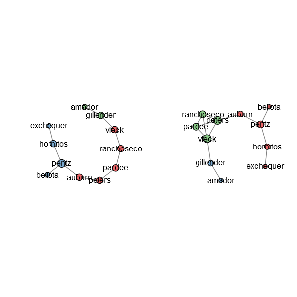

```r
# investigate max spanning tree
plotSoilRelationGraph(m, spanning.tree='max')

# investigate max spanning tree + edges with weights > 75-th pctile
plotSoilRelationGraph(m, spanning.tree=0.75)
```

```r
## Not run:
##D # get similar data from soilweb, for the Pardee series
##D s <- 'pardee'
##D u <- url(URLencode(paste(
##D 'http://casoilresource.lawr.ucdavis.edu/soil_web/reflector_api/soils.php?',
##D 'what=soil_series_component_query&q_string=', s, sep='')))
##D
##D # fetch data
##D d <- read.table(u, sep='|', header=TRUE, stringsAsFactors=FALSE)
##D
##D # normalize component names
##D d$compname <- tolower(d$compname)
##D
##D # keep only major components
##D d <- subset(d, subset=compkind == 'Series')
##D
##D # build adj. matrix and plot
##D m <- component.adj.matrix(d)
##D plotSoilRelationGraph(m, s=s, plot.style='dendrogram')
##D
##D # alter plotting style, see ?plot.phylo
##D plotSoilRelationGraph(m, s=s, plot.style='dendrogram', type='fan')
##D plotSoilRelationGraph(m, s=s, plot.style='dendrogram', type='unrooted', use.edge.length=FALSE)
## End(Not run)
```

[Package *sharpshootR* version 0.7 Index]